# Exploring durations

2023-06-25

# Exploring Durations across Different Languages

```r
library(tidyverse)
library(reshape2)
library(stargazer)
library(jtools)
```

The aim of this research is to investigate the duration of sounds and words across a variety of languages. Specifically, I will examine the differences in duration of vowels and sibilants.

Additionally, I will investigate whether speech rate differs between males and females in various languages, including minority languages.

## Theoretical Background

The International Phonetic Alphabet (IPA) is a standardized set of symbols used to represent the sounds of all languages. While the IPA aims to provide a finite set of segments to unify sounds across languages, it is well-known that the segments are not identical.

One factor that can vary among these segments is duration. Previous research has shown that the duration of vowels and sibilants can differ across languages.

```r
vowels <- c("a", "o", "u", "e", "i")
sibilants <- c("s", "z", "s`", "z`", "s\\", "z\\")
sounds <- append(vowels, sibilants)
```

In this research, I aim to test whether the duration of vowels and sibilants significantly differs across different languages. To do this, I will analyze speech data from the DoReCo dataset.

## Data

DoReCo dataset is available online on https://doreco.huma-num.fr/. I used the core subset of DoReCo which includes 51 languages.

For each language there are a file with phonemes and a file with metadata on speakers. They look as follows.

```r
read_csv(file.path(
    "data",
    sprintf("doreco_%s_core", "even1259"),
    sprintf("doreco_%s_ph.csv", "even1259")
    ))
```

```
## # A tibble: 60,604 × 18
##    lang    file  core_extended speaker ph_ID ph    start   end ref   tx    ft
##    <chr>   <chr> <chr>         <chr>   <chr> <chr> <dbl> <dbl> <chr> <chr> <chr>
##  1 even12… dore… core          AVN     p000… <p:>  0     0.884 <p:>  <p:>  <p:>
##  2 even12… dore… core          AVN     p000… <<fm… 0.884 1.10  0001… Ну, … Ну, …
##  3 even12… dore… core          AVN     p000… o     1.10  1.32  0001… Ну, … Ну, …
##  4 even12… dore… core          AVN     p000… n     1.32  1.46  0001… Ну, … Ну, …
##  5 even12… dore… core          AVN     p000… b     1.46  1.52  0001… Ну, … Ну, …
##  6 even12… dore… core          AVN     p000… i     1.52  1.68  0001… Ну, … Ну, …
##  7 even12… dore… core          AVN     p000… o     1.68  1.76  0001… Ну, … Ну, …
##  8 even12… dore… core          AVN     p000… h     1.76  1.91  0001… Ну, … Ну, …
##  9 even12… dore… core          AVN     p000… o     1.91  1.95  0001… Ну, … Ну, …
## 10 even12… dore… core          AVN     p000… t_j   1.95  1.98  0001… Ну, … Ну, …
## # ℹ 60,594 more rows
## # ℹ 7 more variables: wd_ID <chr>, wd <chr>, mb_ID <chr>, mb <chr>,
## #   `doreco-mb-algn` <lgl>, ps <chr>, gl <chr>
```

```r
read_csv(file.path(
    "data",
    sprintf("doreco_%s_core", "even1259"),
    sprintf("doreco_%s_metadata.csv", "even1259")),
    col_types = "iccccccccccccccc")
```

```
## # A tibble: 36 × 16
##       id name       spk_code spk_age spk_age_c spk_sex rec_date rec_date_c genre
##    <int> <chr>      <chr>    <chr>   <chr>     <chr>   <chr>    <chr>      <chr>
##  1    NA 2008_Tura… GKL      70      certain   m       2008     certain    pers…
##  2    NA 2006_Ozer… VNS      47      certain   m       2006     certain    pers…
##  3    NA 2006_Ozer… VNS      47      certain   m       2006     certain    pers…
##  4    NA 2006_Ozer… VNS      47      certain   m       2006     certain    pers…
##  5    NA 2006_Ozer… RIB      49      certain   f       2006     certain    pers…
##  6    NA 2007_Chir… VKY      53      certain   f       2007     certain    trad…
##  7    NA 2007_Chir… VKY      53      certain   f       2007     certain    trad…
##  8    NA 2007_Chir… VKY      53      certain   f       2007     certain    trad…
##  9    NA 2007_Chir… DMK      54      certain   m       2007     certain    pers…
## 10    NA 2007_Ekon… GNK      75      certain   m       2007     certain    pers…
## # ℹ 26 more rows
## # ℹ 7 more variables: genre_stim <chr>, gloss <chr>, transl <chr>,
## #   sound_quality <chr>, background_noise <chr>, word_tokens <chr>,
## #   extended <chr>
```

### Prepocessing

```r
dataset_by_language <- function(language_name, segments=TRUE) {

  # reading dataset with phonemes

  df <- read_csv(file.path(
    "data",
    sprintf("doreco_%s_core", language_name),
    sprintf("doreco_%s_ph.csv", language_name)
    ))


  # reading dataset with metadata and extracting only spk_code and spk_sex

  meta <- read_csv(file.path(
    "data",
    sprintf("doreco_%s_core", language_name),
    sprintf("doreco_%s_metadata.csv", language_name)),
    col_types = "iccccccccccccccc") %>%
    select(spk_code, spk_sex)

  df %>%
    mutate(
      left_context = lag(ph),
      right_context = lead(ph),
      duration = end - start) %>%
    select(ph, duration, left_context, right_context, speaker) -> df


  # condition on extracting only vowels and sibilants or all segments

  if (segments) {df <- df %>% filter(ph %in% append(vowels, sibilants))}

  df$language <- language_name

  df <- unique(merge(df, meta, by.x = "speaker", by.y = "spk_code"))


  return(df)
}
```

Here I collect data about all vowels and sibilants in 51 languages from DoReCo.

```r
languages <- read_csv("doreco_languages_metadata_v1.2.csv")

dataset <- data.frame()

for (lang in languages$Glottocode) {
  print(lang)
  df <- dataset_by_language(lang)

  df$speaker <- as.character(df$speaker)

  dataset <- bind_rows(dataset, df)

}
```

```
## [1] "anal1239"
## [1] "apah1238"
## [1] "arap1274"
## [1] "bain1259"
## [1] "beja1238"
## [1] "bora1263"
## [1] "cabe1245"
## [1] "cash1254"
## [1] "dolg1241"
## [1] "even1259"
## [1] "goem1240"
## [1] "goro1270"
## [1] "hoch1243"
## [1] "jeha1242"
## [1] "jeju1234"
```

[output cut: 36 more lines]

Dataset:

```r
head(dataset)
```

```
##   speaker ph duration left_context right_context language spk_sex
## 1 Mohtung  a    0.030            h             l anal1239       m
## 2 Mohtung  e    0.102            l             a anal1239       m
## 3 Mohtung  a    0.030            e             m anal1239       m
## 4 Mohtung  e    0.030            l             n anal1239       m
## 5 Mohtung  a    0.090            n             l anal1239       m
## 6 Mohtung  a    0.030         <p:>             N anal1239       m
```

## Analysis

### Segement duration

The data is split by the type of a segment.

```r
vowels_dataset <- dataset %>% filter(ph %in% vowels)
sibilants_dataset <- dataset %>% filter(ph %in% sibilants)
```

Some visualisations on the datasets.

```r
analyse_dataset <- function(df, segments, outliers, ph) {

  df %>%
    select(ph, language) %>%
    unique() %>%
    group_by(ph) %>%
    summarise(n = length(language)) -> smr

  print(smr)

  df %>%
  filter(language %in% sample(languages$Glottocode, 10)) %>%
  ggplot(aes(ph, duration, fill=ph)) +
    geom_violin() +
    facet_wrap(~language) +
    stat_summary(fun=mean, geom="point", size=1, color="white") -> g

  print(g)

  df %>%
    filter(language %in% sample(languages$Glottocode, 10)) %>%
    ggplot(aes(language, duration, fill=language)) +
      geom_violin() +
      facet_wrap(~ph) +
      scale_x_discrete(guide = guide_axis(angle = 90))+
      stat_summary(fun=mean, geom="point", size=1, color="white")+
      ylim(c(0, 0.5)) -> g

  print(g)

  df %>%
    filter(language %in% outliers) %>%
    filter(ph == ph) %>%
    t.test(data=., duration ~ language) -> res

  df %>%
    filter(language %in% outliers) %>%
    filter(ph == ph) %>%
    ggplot(aes(language, duration, fill=language)) +
      geom_boxplot() +
      ggtitle(sprintf("p-value is equal to %s", res$p.value)) -> g

  print(g)

  df %>%
    filter(language %in% outliers) %>%
    filter(ph == ph) %>%
    t.test(data=., duration ~ language)

  for (segment in segments) {
    df %>%
      filter(ph == segment) %>%
      aov(duration ~ language, data=.) -> res

    print(sprintf("P-value of ANOVA is equal to %s",
                  summary(res)[[1]][["Pr(>F)"]][1]))

    TukeyHSD(res) -> tukey

    data.frame(tukey$language) %>%
      filter(`p.adj` < 0.05) -> signf

    print(sprintf("%s: %s pairs out of %s are significant (%s%%)",
                  segment, nrow(signf), nrow(tukey$language),
                  round(nrow(signf) / nrow(tukey$language) * 100)
                  )
          )  }
}
```

I show:

```r
analyse_dataset(vowels_dataset, vowels,
                outliers=c("ruul1235", "kama1351"), ph="o")
```

```
## # A tibble: 5 × 2
##   ph        n
##   <chr> <int>
## 1 a        48
## 2 e        39
## 3 i        48
## 4 o        40
## 5 u        45
```

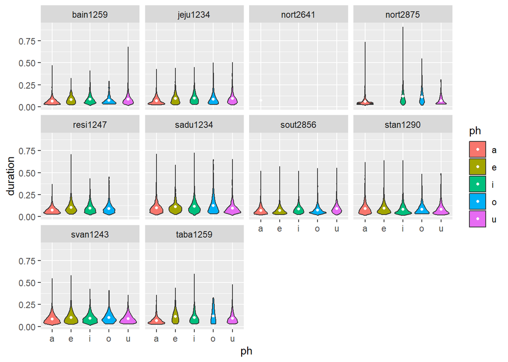

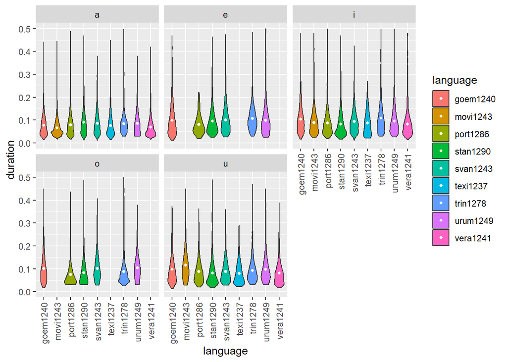

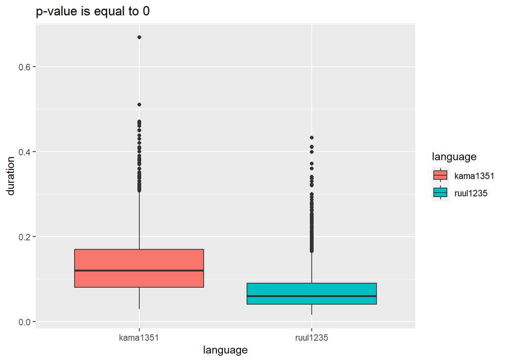

```
## [1] "P-value of ANOVA is equal to 0"
## [1] "a: 867 pairs out of 1128 are significant (77%)"
## [1] "P-value of ANOVA is equal to 0"
## [1] "o: 434 pairs out of 780 are significant (56%)"
## [1] "P-value of ANOVA is equal to 0"
## [1] "u: 601 pairs out of 990 are significant (61%)"
## [1] "P-value of ANOVA is equal to 0"
## [1] "e: 432 pairs out of 741 are significant (58%)"
## [1] "P-value of ANOVA is equal to 0"
## [1] "i: 799 pairs out of 1128 are significant (71%)"
```

```r
analyse_dataset(sibilants_dataset, sibilants,
                outliers = c("apah1238", "beja1238"), ph="s")
```

```
## # A tibble: 6 × 2
##   ph        n
##   <chr> <int>
## 1 "s"      49
## 2 "s\\"     4
## 3 "s`"      3
## 4 "z"      25
## 5 "z\\"     3
## 6 "z`"      2
```

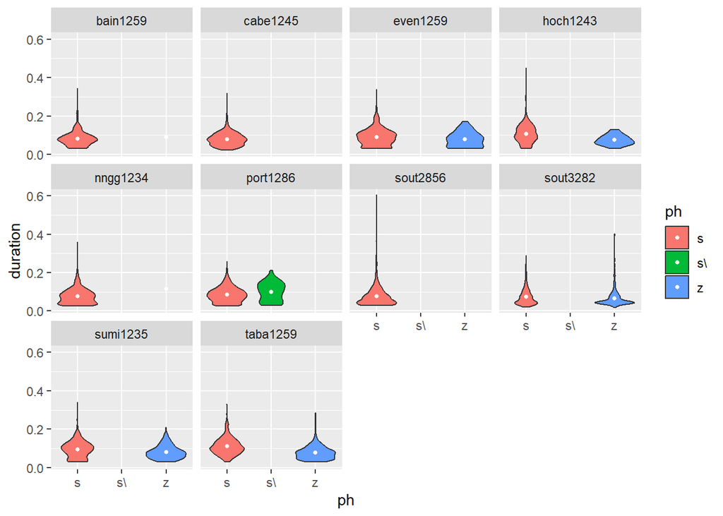

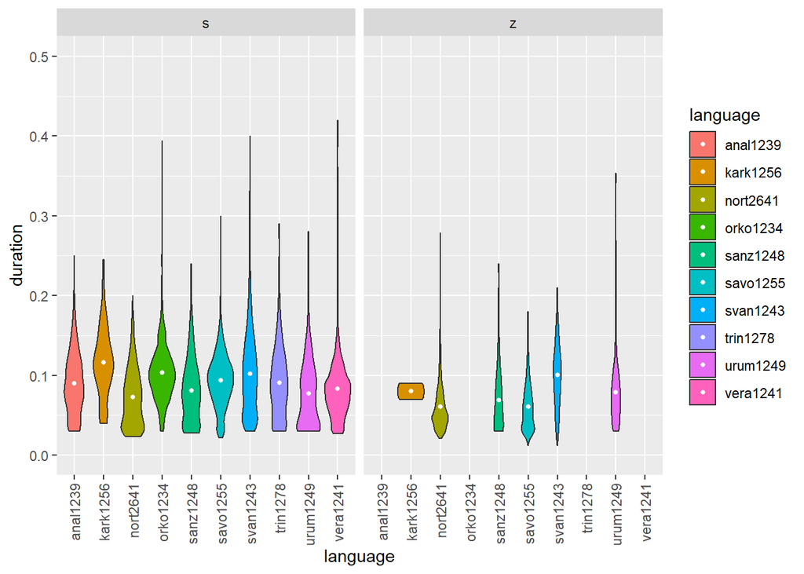

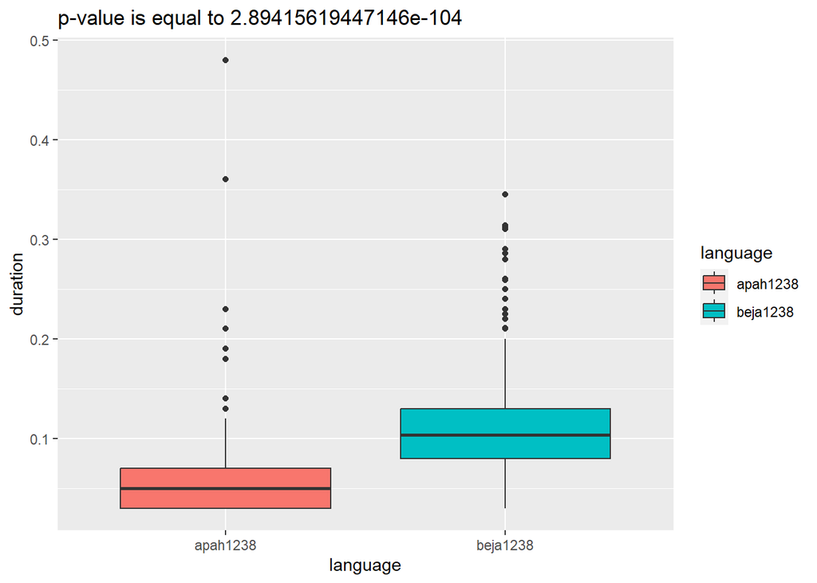

```
## [1] "P-value of ANOVA is equal to 0"
## [1] "s: 731 pairs out of 1176 are significant (62%)"
## [1] "P-value of ANOVA is equal to 6.02891187405115e-194"
## [1] "z: 79 pairs out of 300 are significant (26%)"
## [1] "P-value of ANOVA is equal to 9.80978589761965e-19"
## [1] "s`: 3 pairs out of 3 are significant (100%)"
## [1] "P-value of ANOVA is equal to 1.28024582396052e-06"
## [1] "z`: 1 pairs out of 1 are significant (100%)"
## [1] "P-value of ANOVA is equal to 0.00886155112718503"
## [1] "s\\: 3 pairs out of 6 are significant (50%)"
## [1] "P-value of ANOVA is equal to 8.62459272263106e-22"
## [1] "z\\: 2 pairs out of 3 are significant (67%)"
```

Now, I proceed to Pearson’s correlation. My goal was to show that languages are not simply divided into fast and slow, so the mean duration of the segments of one type do not directly influence the mean duration of another type.

```r
# labeling segments either as v[owel] or s[ibilant]
dataset$type <- ifelse(dataset$ph %in% vowels, "v", "s")

# counting mean duration
dataset %>%
  group_by(type, language) %>%
  summarise(dur = mean(duration)) -> smr

# reshaping into wide format
reshape(as.data.frame(smr), direction = "wide",
        idvar="language", timevar="type") %>%
  drop_na() -> wide_smr

# calculating
cor(wide_smr$dur.s, wide_smr$dur.v)
```

```
## [1] 0.2658918
```

The correlation score is very low, so my hypothesis is correct.

Now I proceed to linear regression prediction. Unfortunately, I have a lot of data and my devices are unable to compute it based on the whole dataset. So, I randomly choose 10,000 rows and belive that the result can be extrapolated on the whole data.

```r
label_encoding <- function(column) {
  return(as.numeric(as.factor(column)))
}

dataset %>%
  mutate(left_context_cat=label_encoding(left_context),
         right_context_cat=label_encoding(right_context),
         language_cat=label_encoding(language)
         ) -> data

data_kk <- data[sample(nrow(data), 10000), ]



fit <- lm(
  duration ~ left_context_cat + right_context_cat + language_cat,
  data=data_kk
  )
summ(fit)
```

```
## MODEL INFO:
## Observations: 10000
## Dependent Variable: duration
## Type: OLS linear regression
##
## MODEL FIT:
## F(3,9996) = 2.75, p = 0.04
## R² = 0.00
## Adj. R² = 0.00
##
## Standard errors: OLS
## ------------------------------------------------------
##                            Est.   S.E.   t val.      p
## ----------------------- ------- ------ -------- ------
## (Intercept)                0.10   0.00    22.48   0.00
## left_context_cat          -0.00   0.00    -2.77   0.01
## right_context_cat         -0.00   0.00    -0.62   0.54
## language_cat               0.00   0.00     0.50   0.61
## ------------------------------------------------------
```

Linear regression pretty failed, R2 is near zero. So, the analysis of p-values here seems meaningless.

### Speech rate

Now I turn to the second part of the analysis: speech rate. Research suggests that speech rate can differ between males and females in certain languages, and this difference has been investigated in well-documented languages (Pépiot 2014). However, little research has been conducted on the speech rate differences between genders in minority languages.

```r
languages <- read_csv("doreco_languages_metadata_v1.2.csv")

dataset_words <- data.frame()

for (lang in languages$Glottocode) {
  print(lang)
  df <- dataset_by_language(lang, FALSE)

  df$speaker <- as.character(df$speaker)

  dataset_words <- bind_rows(dataset_words, df)

}
```

```
## [1] "anal1239"
## [1] "apah1238"
## [1] "arap1274"
## [1] "bain1259"
## [1] "beja1238"
## [1] "bora1263"
## [1] "cabe1245"
## [1] "cash1254"
## [1] "dolg1241"
## [1] "even1259"
## [1] "goem1240"
## [1] "goro1270"
## [1] "hoch1243"
## [1] "jeha1242"
## [1] "jeju1234"
```

[output cut: 36 more lines]

This time, it is important to clear the dataset since there are some symbols that indicate different types of pauses, which I do not know how to take into account yet.

```r
dataset_words %>%
  filter(!grepl("[<>{}]", ph)) -> dataset_words_clear
```

Now, for each language I count mean durations across different speakers and test whether the distribution is shifted in a way that males are at one end of a scale and women are at the other. I use Mann–Whitney U test to estimate whether the shift is not equal to zero.

```r
wilc_data <- data.frame()

for (lang in languages$Glottocode) {
  dataset_words_clear %>%
    filter(language == lang) %>%
    group_by(speaker, spk_sex) %>%
    summarise(dur = mean(duration)) -> smr

  if (length(unique(smr$spk_sex)) == 2) {
    res <- wilcox.test(dur ~ spk_sex,
                       data = smr,
                       exact = FALSE)$p.value
  } else {res <- NA}

  wilc_data <- bind_rows(wilc_data,
                         data.frame(language = as.character(lang),
                                    p.value = res))
}

wilc_data %>%
  filter(p.value < 0.05)
```

```
##   language    p.value
## 1 orko1234 0.02518146
```

Among all languages, only one showed significant results: Orkon-Fanbak (Austronesian). However, the results are puzzling since it is usually claimed that female speech rate is greater. However, we see from the data that for these languages mean male duration is usually less than mean female duration. However, of course this data is not enough to make far-reaching conclusions.

```r
dataset_words_clear %>%
  filter(language == "orko1234") %>%
  group_by(speaker, spk_sex) %>%
  summarise(mean_dur = mean(duration)) -> orko

orko[order(orko$mean_dur), ]
```

```
## # A tibble: 10 × 3
## # Groups:   speaker [10]
##    speaker spk_sex mean_dur
##    <chr>   <chr>      <dbl>
##  1 RT1     m         0.0796
##  2 WS1     m         0.0820
##  3 TH1     m         0.0827
##  4 WS3     f         0.0857
##  5 SJ1     m         0.0858
##  6 ET1     f         0.0875
##  7 IR1     f         0.0876
##  8 AT1     f         0.0895
##  9 RL1     f         0.0943
## 10 LM1     f         0.0955
```